# Lab6-8914620

## ***LABORATORY 6*** - ANEESH KRISHNA RAMESH - 8914620

#### **Binary logistic regression**

```python
import pandas as pd
import numpy as np

import matplotlib.pyplot as plot
import seaborn as sb

from sklearn.datasets import load_iris
from sklearn.model_selection import train_test_split
from sklearn.linear_model import LogisticRegression
from sklearn.preprocessing import RobustScaler
from sklearn.metrics import accuracy_score, confusion_matrix
```

```python
irisDF = load_iris()
# irisDF_ds = pd.DataFrame(irisDF['data'], columns=irisDF['feature_names']).assign(Species=irisDF['target_names'][irisDF['target']])
irisDF_ds = pd.DataFrame(irisDF['data'], columns=irisDF['feature_names'])

xVal = irisDF.data
yVal = irisDF.target
display(irisDF_ds.head())

# adding target table
irisDF_ds['target'] = yVal
display(irisDF_ds.head())
```

|  | sepal length (cm) | sepal width (cm) | petal length (cm) | petal width (cm) |
| --- | --- | --- | --- | --- |
| 0 | 5.1 | 3.5 | 1.4 | 0.2 |
| 1 | 4.9 | 3.0 | 1.4 | 0.2 |
| 2 | 4.7 | 3.2 | 1.3 | 0.2 |
| 3 | 4.6 | 3.1 | 1.5 | 0.2 |
| 4 | 5.0 | 3.6 | 1.4 | 0.2 |

|  | sepal length (cm) | sepal width (cm) | petal length (cm) | petal width (cm) | target |
| --- | --- | --- | --- | --- | --- |
| 0 | 5.1 | 3.5 | 1.4 | 0.2 | 0 |
| 1 | 4.9 | 3.0 | 1.4 | 0.2 | 0 |
| 2 | 4.7 | 3.2 | 1.3 | 0.2 | 0 |
| 3 | 4.6 | 3.1 | 1.5 | 0.2 | 0 |
| 4 | 5.0 | 3.6 | 1.4 | 0.2 | 0 |

> The below shows the correlation between all features of the Iris Dataset

```python
irisDF_ds.corr()
```

|  | sepal length (cm) | sepal width (cm) | petal length (cm) | petal width (cm) | target |
| --- | --- | --- | --- | --- | --- |
| sepal length (cm) | 1.000000 | -0.117570 | 0.871754 | 0.817941 | 0.782561 |
| sepal width (cm) | -0.117570 | 1.000000 | -0.428440 | -0.366126 | -0.426658 |
| petal length (cm) | 0.871754 | -0.428440 | 1.000000 | 0.962865 | 0.949035 |
| petal width (cm) | 0.817941 | -0.366126 | 0.962865 | 1.000000 | 0.956547 |
| target | 0.782561 | -0.426658 | 0.949035 | 0.956547 | 1.000000 |

```python
display(irisDF_ds[irisDF_ds['target'] == 2].describe())
```

|  | sepal length (cm) | sepal width (cm) | petal length (cm) | petal width (cm) | target |
| --- | --- | --- | --- | --- | --- |
| count | 50.00000 | 50.000000 | 50.000000 | 50.00000 | 50.0 |
| mean | 6.58800 | 2.974000 | 5.552000 | 2.02600 | 2.0 |
| std | 0.63588 | 0.322497 | 0.551895 | 0.27465 | 0.0 |
| min | 4.90000 | 2.200000 | 4.500000 | 1.40000 | 2.0 |
| 25% | 6.22500 | 2.800000 | 5.100000 | 1.80000 | 2.0 |
| 50% | 6.50000 | 3.000000 | 5.550000 | 2.00000 | 2.0 |
| 75% | 6.90000 | 3.175000 | 5.875000 | 2.30000 | 2.0 |
| max | 7.90000 | 3.800000 | 6.900000 | 2.50000 | 2.0 |

```python
irisDF_ds['targetBinary'] = (irisDF_ds['target'] == 2).astype(int)
modIrisDF = irisDF_ds.drop(['target', 'targetBinary'], axis=1)
```

### **Splitting training and testing data**

```python
X_train, X_test, y_train, y_test = train_test_split(modIrisDF, irisDF_ds['targetBinary'], test_size=0.2, random_state=42)
```

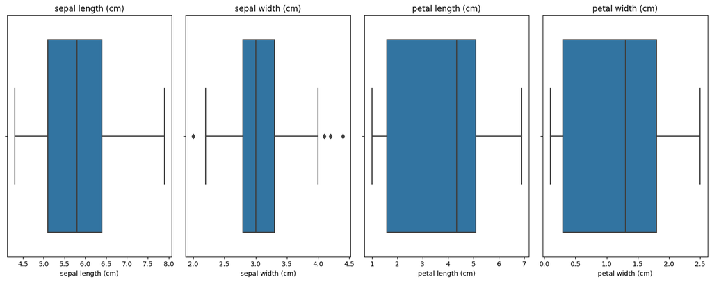

```python
plot.figure(figsize=(12, 2))

fig, axes = plot.subplots(nrows=1, ncols=4, figsize=(15, 6))
for i, feature in enumerate( modIrisDF.columns):
    ax = axes[i]
    sb.boxplot(data=irisDF_ds, x=feature, ax=ax)
    ax.set_title(feature)

plot.tight_layout()
plot.show()
```

> We are scaling data using ***Robust Scaler*** to pass normalized values to the model. We're using Robust scaler because it's not sensitive to outliers.

> Although the above box plots indiciate that don't have much outliers in most of the features, I will still use ***Robust Scaler***

> We can also use Scalers like ***MinMaxScaler*** or ***Standard Scaler***

```python
scaler = RobustScaler()
X_train_scaled = scaler.fit_transform(X_train)
X_test_scaled = scaler.transform(X_test)
```

### **Logistic Regression** - Training

```python
# Training the logistic regression model
model = LogisticRegression()
model.fit(X_train_scaled, y_train)

y_pred = model.predict(X_test_scaled)
print("Predictions : ",y_pred)
```

```
Predictions :  [0 0 1 0 0 0 0 1 0 0 1 0 0 0 0 0 1 0 0 1 0 1 0 1 1 1 1 1 0 0]
```

#### **NOTE**: Unlike Leniar regression models, Logistical regression models do not output continous values, they predict binary values. So it's 0 or 1s

```python
misclassified = X_test[y_test != y_pred]
display(misclassified)
```

|  | sepal length (cm) | sepal width (cm) | petal length (cm) | petal width (cm) |
| --- | --- | --- | --- | --- |

> Based on the above output, there were ***no misclassified samples***. The understandinig is that the model has so far been* *completely accurate**. Let's go through if that was the case by the below metrics

```python
# Calculating accuracy
accuracy = accuracy_score(y_test, y_pred)
print("Model accuracy ::: ", accuracy,"\n")

# Calculating confusion matrix
confusion_matrix = confusion_matrix(y_test, y_pred)
print("Confusion_matrix ::: \n", confusion_matrix)
```

```
Model accuracy :::  1.0

Confusion_matrix :::
 [[19  0]
 [ 0 11]]
```

```python
irisDF_ds.columns
```

```
Index(['sepal length (cm)', 'sepal width (cm)', 'petal length (cm)',
       'petal width (cm)', 'target', 'targetBinary'],
      dtype='object')
```

### **Plotting the relationship between the features** - (Virginica v Non-Virginica)

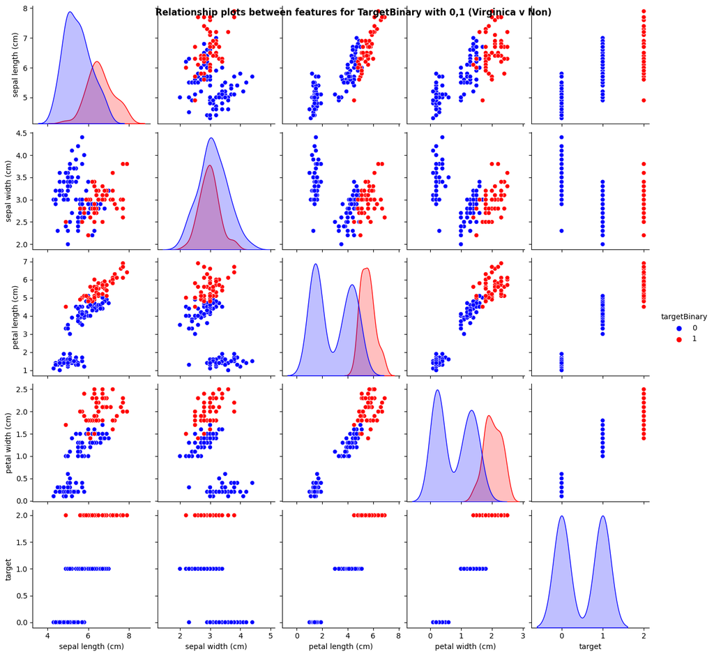

```python
sb.pairplot(data=irisDF_ds, hue='targetBinary', palette={0: 'blue', 1: 'red'})
plot.suptitle("Relationship plots between features for TargetBinary with 0,1 (Virginica v Non)",fontweight='bold')
plot.show()
```

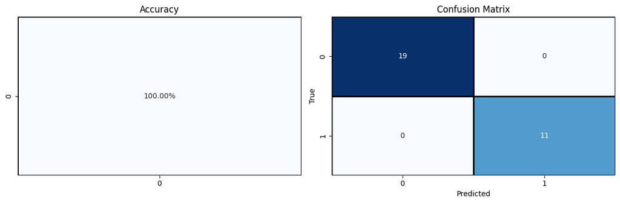

```python
plot.figure(figsize=(12, 4))

plot.subplot(121)
sb.heatmap([[accuracy]], annot=True, cbar=False, cmap="Blues", fmt=".2%", linewidths=1, linecolor="black", )
plot.title("Accuracy")


plot.subplot(122)
sb.heatmap(confusion_matrix, annot=True, fmt="d", cmap="Blues", cbar=False, linewidths=1, linecolor="black")
plot.xlabel("Predicted")
plot.ylabel("True")
plot.title("Confusion Matrix")

plot.tight_layout()
plot.show()
```

## ***OBSERVATIONS***

As we can see from accuracy and confusion matrix above. The model correctly predicts the values correctly.

The bottom right is the ***True Positive*** case, it predicted 11 cases that were correct.

This is also observed with the accuracy metric of 1. Which suggests that the accuracy is 100% & the False Negatives and False positives being 0.